# Add images to plots

- Show All Code
- Hide All Code
- View Source

# Pre-requisites:

The following chunk sets up rules for all the chunks in the document. I set the knits options for the chunks so that by default messages generated by R are not displayed.

Please notice the alternative way to name the chunk (within the curly brackets, and not after the #| as we’ve seen before). Similarly, other YAML options that we have seen listed after #| could be just used within the curly brackets. For example `{r chunk_name, include=FALSE}.

**Click here to show the code**

```r
knitr::opts_chunk$set(message = FALSE)
```

In this second package I load all the necessary packages. I also use `here`for file referencing and automatic working directory setting.

**Click here to show the code**

```r
pacman::p_load(here, tidyverse, ggimage, palmerpenguins, dplyr, ggpattern, patchwork, png, rasterImage, grid)
here::i_am("images_in_R_plots.qmd")
```

# Add an image in R plot

Here I want to show you how to add images to your plot. There are different ways to do this, depedning on what you would like to achieve.

Choose a tab for different ways to add the logo image to ggplots:

**using ggimage**

Adapted from Albert Rapp’s [blog post on the topic](https://albert-rapp.de/posts/ggplot2-tips/27_images/27_images).

The following is a plot using the [Palmer Penguins Data Set](https://allisonhorst.github.io/palmerpenguins/) taken from their [examples](https://allisonhorst.github.io/palmerpenguins/articles/examples.html).

**Click here to show the code**

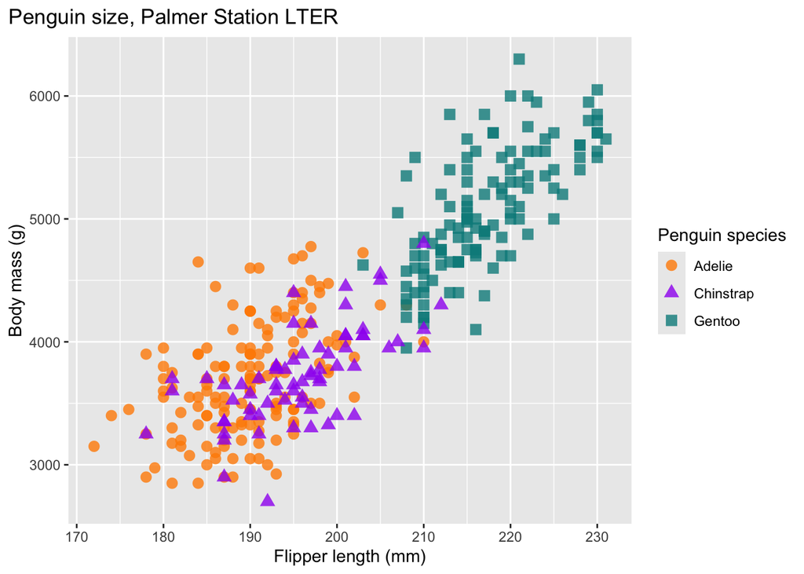

```r
mass_flipper <- ggplot(data = penguins,
                       aes(x = flipper_length_mm,
                           y = body_mass_g)) +
  geom_point(aes(color = species,
                 shape = species),
             size = 3,
             alpha = 0.8) +
  scale_color_manual(values = c("darkorange","purple","cyan4")) +
  labs(title = "Penguin size, Palmer Station LTER",
       x = "Flipper length (mm)",
       y = "Body mass (g)",
       color = "Penguin species",
       shape = "Penguin species") +
  theme(legend.position.inside = c(0.2, 0.7),
        plot.title.position = "plot",
        plot.caption = element_text(hjust = 0, face= "italic"),
        plot.caption.position = "plot")

mass_flipper
```

**ImportantRepetition - think back**

Are you familiar with all the different parts of the plot? Does anything look familiar from earlier exercises?

Now we want to add the logo to the plot.

With `ggimage` we can add an image in a separate `geom_image()` and position the image within the plot on the same coordinates that are also used in the original plot:

**Click here to show the code**

[figure not shown]

```r
ggplot(data = penguins,
                       aes(x = flipper_length_mm,
                           y = body_mass_g)) +
  geom_point(aes(color = species,
                 shape = species),
             size = 3,
             alpha = 0.8) +
  scale_color_manual(values = c("darkorange","purple","cyan4")) +
  labs(title = "Penguin size, Palmer Station LTER",
       x = "Flipper length (mm)",
       y = "Body mass (g)",
       color = "Penguin species",
       shape = "Penguin species") +
  theme(legend.position.inside = c(0.2, 0.7),
        plot.title.position = "plot",
        plot.caption = element_text(hjust = 0, face= "italic"),
        plot.caption.position = "plot")+
  geom_image(
    data = tibble(flipper_length_mm = 220, body_mass_g = 3000),
    aes(image = "penguin_logo.png")
  )
```

We can then adjust the size of the logo with `size`:

**Click here to show the code**

[figure not shown]

```r
ggplot(data = penguins,
                       aes(x = flipper_length_mm,
                           y = body_mass_g)) +
  geom_point(aes(color = species,
                 shape = species),
             size = 3,
             alpha = 0.8) +
  scale_color_manual(values = c("darkorange","purple","cyan4")) +
  labs(title = "Penguin size, Palmer Station LTER",
       x = "Flipper length (mm)",
       y = "Body mass (g)",
       color = "Penguin species",
       shape = "Penguin species") +
  theme(legend.position.inside = c(0.2, 0.7),
        plot.title.position = "plot",
        plot.caption = element_text(hjust = 0, face= "italic"),
        plot.caption.position = "plot")+
  geom_image(
    data = tibble(flipper_length_mm = 220, body_mass_g = 3000),
    aes(image = "penguin_logo.png"),
    size = 0.5
  )
```

**Note**

See how the image is restricted to the plotting area and cut off?

**inside geoms**

Adapted from Albert Rapp’s [blog post on the topic](https://albert-rapp.de/posts/ggplot2-tips/27_images/27_images).

With this technique we can spice up the plot inside ggplot geoms. Now we will pretend that the following plot is pengion related and add an image inside the geom_tiles (downloaded from [flaticon](https://www.flaticon.com/free-icon/penguin_1998747?term=penguin&page=1&position=3&origin=search&related_id=1998747)).

**Click here to show the code**

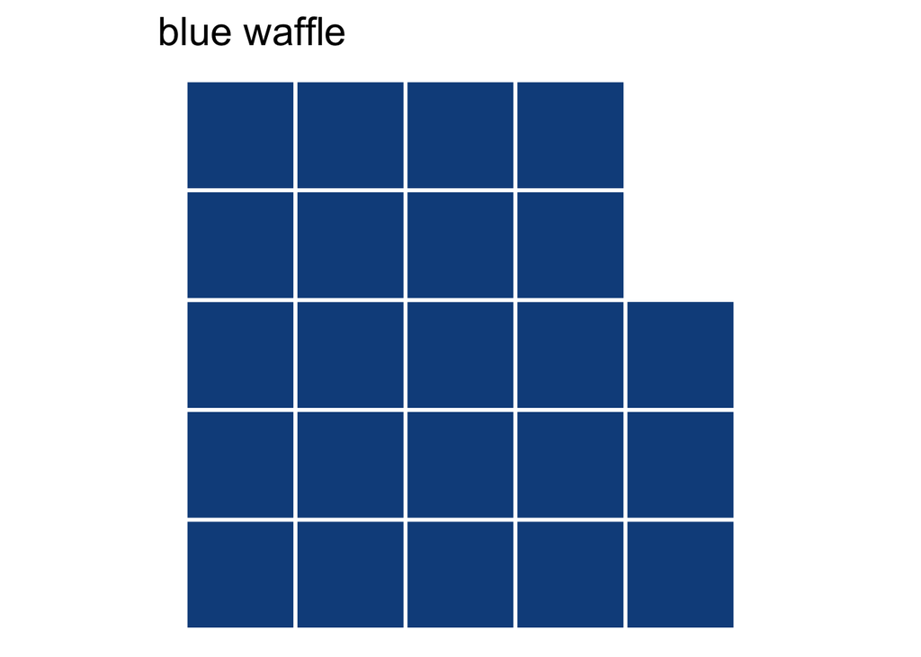

```r
tibble(id = 0:22, row = id %% 5, col = id %/% 5) |>
  ggplot(aes(x = col, y = row)) +
  geom_tile(fill = 'dodgerblue4', col = 'white', linewidth = 1) +
  coord_equal() +
  labs(title = 'blue waffle') +
  theme_void(base_size = 18)
```

**Click here to show the code**

[figure not shown]

```r
library(ggpattern)
tibble(id = 0:22, row = id %% 5, col = id %/% 5) |>
  ggplot(aes(x = col, y = row)) +
  geom_tile_pattern(
    fill = 'dodgerblue4',
    col = 'white',
    linewidth = 1,
    pattern = 'image',
    pattern_filename = 'penguin.png'
  ) +
  coord_equal() +
  labs(
    title = 'happy waffle',
    caption = 'Flaticon Icon by Flat Icons'
  ) +
  theme_void(base_size = 18)
```

More modifications you can make to this plot can be found in the original [blog post](https://albert-rapp.de/posts/ggplot2-tips/27_images/27_images).

**using patchwork**

With the package `png` we can make a r object out of the penguin logo (there are corresponding packages for jpeg files for example).

With the function `rasterGrob` from the `grid` package we can transform this r object into a ggplot compatible object.

We can then use `patchwork`’s ìnset_element()`function to place the image into the plot.

**Click here to show the code**

[figure not shown]

```r
img <- readPNG("penguin_logo.png")

# Convert to rasterGrob for use in ggplot from package grid
img_grob <- rasterGrob(img, interpolate = TRUE)

bill_len_dep <- ggplot(data = penguins,
                         aes(x = bill_length_mm,
                             y = bill_depth_mm,
                             group = species)) +
  geom_point(aes(color = species,
                 shape = species),
             size = 3,
             alpha = 0.8) +
  geom_smooth(method = "lm", se = FALSE, aes(color = species)) +
  scale_color_manual(values = c("darkorange","purple","cyan4")) +
  labs(title = "Penguin bill dimensions",
       x = "Bill length (mm)",
       y = "Bill depth (mm)",
       color = "Penguin species",
       shape = "Penguin species") +
  theme(legend.position = c(0.85, 0.15),
        plot.title.position = "plot",
        plot.caption = element_text(hjust = 0, face= "italic"),
        plot.caption.position = "plot")

bill_len_dep + inset_element(img_grob, 0.6, 0.6, 1, 1)
```

We can also use the output from `rasterGrob` to place plots side by side:

**Click here to show the code**

[figure not shown]

```r
bill_len_dep + img_grob
```

More on using `patchwork` to insert images to ggplot plots can be found [here](https://patchwork.data-imaginist.com/reference/inset_element.html#arguments).